# Bolt — Speculative Project · Nina Briantseva

Speculative Project · 2025

Bolt safety quiz

RoleUX/UI Design

TypeSpeculative

ToolFigma

Year2025

[video not shown]

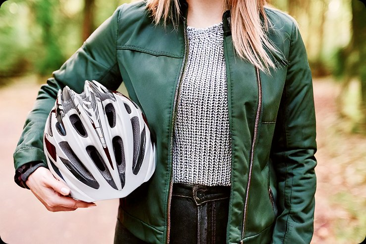

The Problem

## Safety through awareness

As mini mopeds launch across Tallinn, public concerns have arisen — they're seen as unsafe, disruptive, and often misused.

But many of these issues stem from a simple lack of awareness, especially among younger or first-time users who jump on a moped without knowing the basic rules of the road.

Test the feature

Core Insight

The problem isn't recklessness — it's ignorance. A small moment of education, placed at the right point in the journey, can shift behaviour.

The Solution

## Quick safety quizzes

[figure not shown]

We propose adding Quick Safety Quizzes to the Bolt app — short, gamified tests that educate users on the most important safety rules at exactly the right moment.

By analysing the user journey, the ideal placement was found: the quiz appears either randomly after booking a moped, or when the user scrolls through the booking screen.

A character was crafted to respond to both correct and incorrect answers — adding a layer of playfulness that transforms each quiz into a moment of genuine delight.

01Appears randomly after booking a moped or during the booking screen scroll

02Takes only 30 seconds — minimal friction, maximum impact

03Questions are obvious by design, focusing on awareness, not testing knowledge

04Some answers are followed by a short, clear explanation to reinforce the message

Mockups

## The screens

[figure not shown]

[figure not shown]